# Impacts of species diversity on the light distribution in canopies

—————- Leaf Optical Properties, Overcast scenario —————-

Elena Plekhanova

October 17, 2019

## DART modelling

We model trees - using DART radiative transfer model - as trunks and clouds of triangles with realistic leaf optical properties. To test different species diversity scenarios, we test all combinations of species (1, 2, … 6 species in even mixtures).

```r
diff_betw_mix_and_av_of_mon = function(subdat, Nscenes_loc = Nscenes, Nspecies_loc = Nspecies) {

  subdat_crown = as.data.frame(subdat[subdat$height_m != 1,])
  aggdat = aggregate(abs_mean ~ height_m + pos + num_of_species + scenetype, data = subdat_crown, FUN = "mean")
  mix_tab = lapply(unique(aggdat$scenetype), function(SCTYPE) {
    res_tab = lapply(unique(aggdat$pos[as.numeric(aggdat$num_of_species) > 1]), function(POS) {
      av_mixture = subset(aggdat, pos == POS & scenetype == SCTYPE, abs_mean)
      abs_of_monocultures = lapply(unique(subdat_crown$species[subdat_crown$pos == POS]), function(x) {
        position_of_mon = subdat_crown$pos[subdat_crown$species == x &
                                             subdat_crown$num_of_species == 1 & subdat_crown$scenetype == SCTYPE][1]
        res = subset(aggdat, pos == position_of_mon & scenetype == SCTYPE, select = abs_mean)
        return(res)
      })

      av_monocultures = apply(do.call(rbind.data.frame, list(abs_of_monocultures)), 1, mean)


      one_mix = data.frame( (av_mixture[,1] - av_monocultures), c(1:nrow(av_mixture)), rep(POS, nrow(av_mixture)))
      colnames(one_mix) = c("abs_mean", "height_m", "pos")

      one_mix$diff_sum = rep(round(sum(one_mix$abs_mean), 3), nrow(one_mix))
      one_mix$num_of_species = rep(aggdat$num_of_species[aggdat$pos == POS][1], nrow(one_mix))

      return(one_mix)
    })
    res_tab = do.call(rbind.data.frame, res_tab)
    res_tab$scenetype = SCTYPE
    return(res_tab)
  })
  mix_tab = do.call(rbind.data.frame, mix_tab)

  return(mix_tab)
}
diff_betw_sp_in_mix_and_in_mon = function(subdat, Nscenes_loc = Nscenes, Nspecies_loc = Nspecies) {

  subdat_crown = as.data.frame(subdat[subdat$height_m != 1,])
  aggdat = aggregate(abs_mean ~ height_m + pos + num_of_species + scenetype + species, data = subdat_crown, FUN = "mean")
  aggdat = aggregate(abs_mean ~ pos + num_of_species + scenetype + species, data = aggdat, FUN = "sum")

  mix_tab = lapply(unique(aggdat$scenetype), function(SCTYPE) {
    res_tab = lapply(unique(aggdat$pos[as.numeric(aggdat$num_of_species) > 1]), function(POS) {
      av_mix = subset(aggdat, pos == POS & scenetype == SCTYPE)
      sps = unique(av_mix$species)
      av_mix_sp1 = av_mix$abs_mean[av_mix$species == sps[1]]
      av_mix_sp2 = av_mix$abs_mean[av_mix$species == sps[2]]
      av_mon_sp1 = subset(aggdat, species == sps[1] & scenetype == SCTYPE & num_of_species == 1)$abs_mean
      av_mon_sp2 = subset(aggdat, species == sps[2] & scenetype == SCTYPE & num_of_species == 1)$abs_mean
      one_mix = data.frame(cbind(c((av_mix_sp1 - av_mon_sp1)[1], (av_mix_sp2 - av_mon_sp2)[1]),
                                 c(av_mon_sp1, av_mon_sp2),
                            rep(POS, 2) ))

      colnames(one_mix) = c("abs_mean", "mon_abs", "pos")
      one_mix$diff_mon = abs((av_mon_sp1 - av_mon_sp2)[1])
      one_mix$diff_mix = abs((av_mix_sp1 - av_mix_sp2)[1])
      one_mix$species = sps
      one_mix$name_species = paste0(sps[1], " + ", sps[2])

      return(one_mix)
    })
    res_tab = do.call(rbind.data.frame, res_tab)
    res_tab$scenetype = SCTYPE
    return(res_tab)
  })
  mix_tab = do.call(rbind.data.frame, mix_tab)

  return(mix_tab)
}
```

```r
library(ggplot2)
library(gridExtra)
#library(dplyr)
library(viridis)
library(plotly)

path_lop = "C:/Users/Gast/DART/user_data/simulations/Output_data/lop6_abs_90_db/profiles.csv"
path_lad = "C:/Users/Gast/DART/user_data/simulations/Output_data/lad6_abs_90_db/profiles_90_plag.csv"
path_lop_30 = "C:/Users/Gast/DART/user_data/simulations/Output_data/lop6_abs_90_db/profiles_30.csv"
path_lad_30 = "C:/Users/Gast/DART/user_data/simulations/Output_data/lad6_abs_90_db/profiles_30_plag.csv"
path_lop_ov = "C:/Users/Gast/DART/user_data/simulations/Output_data/lop6_abs_overcast_db/profiles.csv"
path_lad_ov = "C:/Users/Gast/DART/user_data/simulations/Output_data/lad6_abs_90_db/profiles_overcast_plag.csv"

Ncomb = 63
Nscenes = 3
Nspecies = 6
#WAVE_RANGE = "VIS"

read_data = function(path, scenetype_var = 1) {
  dat = read.csv(path)
  cumsumm = cumsum(unlist(sapply(c(1:Nspecies), function(x) choose(Nspecies, x))))
  the_list_of_comb = sapply(c(1:Nspecies), function(k) sapply(c(1:choose(Nspecies, k)), function(i) combn(Nspecies, k)[,i]))
  the_list_of_sp = unlist(sapply(c(2:Nspecies), function(j) { x = the_list_of_comb[[j]]
  res = split(x, rep(1:ncol(x), each = nrow(x)))
    return(res)}), recursive = FALSE)
  dat$num_of_species = as.factor(dat$num_of_species)
  dat$species = as.factor(dat$species)
  subdat = dat[dat$scenetype == scenetype_var,]
  subdat_crown = as.data.frame(subdat[subdat$height_m != 1,])

  return(subdat_crown)
}

read_and_agg_data = function(path, scenetype_var = 1) {
  subdat_crown = read_data(path, scenetype_var)
  aggdat = aggregate(albedo ~ pos + num_of_species + band, data = subdat_crown, FUN = "mean")
  ## ScalingVIS and NIR ranges
  aggdat$albedo[aggdat$band == "VIS"] = (aggdat$albedo[aggdat$band == "VIS"]*4)/11
  aggdat$albedo[aggdat$band == "NIR"] = (aggdat$albedo[aggdat$band == "NIR"]*18)/11

  aggdat = aggregate(albedo ~ pos + num_of_species, data = aggdat, FUN = "mean")

  cumsumm = cumsum(unlist(sapply(c(1:Nspecies), function(x) choose(Nspecies, x))))
  diffs = lapply(c(2:Nspecies), function(k) sapply(c(1:choose(Nspecies, k)), function(i)
    aggdat$albedo[i+cumsumm[k-1]] - sum(aggdat$albedo[combn(Nspecies, k)[,i]])/k))
  diffs = as.data.frame(cbind(unlist(diffs), aggdat$num_of_species[-c(1:6)]))
  colnames(diffs) = c("differences", "num_of_species")
  diffs$num_of_species = as.factor(diffs$num_of_species)
  return(diffs)
}
```

```r
library(ggplot2)
library(gridExtra)
#library(dplyr)
library(viridis)
library(plotly)
path_lop = "C:/Users/Gast/DART/user_data/simulations/Output_data/lop6_abs_90_db/profiles.csv"
path_lad = "C:/Users/Gast/DART/user_data/simulations/Output_data/lad6_abs_90_db/profiles_90_plag.csv"
path_lop_30 = "C:/Users/Gast/DART/user_data/simulations/Output_data/lop6_abs_90_db/profiles_30.csv"
path_lad_30 = "C:/Users/Gast/DART/user_data/simulations/Output_data/lad6_abs_90_db/profiles_30_plag.csv"
path_lop_ov = "C:/Users/Gast/DART/user_data/simulations/Output_data/lop6_abs_overcast_db/profiles.csv"
path_lad_ov = "C:/Users/Gast/DART/user_data/simulations/Output_data/lad6_abs_90_db/profiles_overcast_plag.csv"
Ncomb = 63
Nscenes = 3
Nspecies = 6
#WAVE_RANGE = "VIS"
read_data = function(path, scenetype_var = 1) {
  dat = read.csv(path)
  cumsumm = cumsum(unlist(sapply(c(1:Nspecies), function(x) choose(Nspecies, x))))
  the_list_of_comb = sapply(c(1:Nspecies), function(k) sapply(c(1:choose(Nspecies, k)), function(i) combn(Nspecies, k)[,i]))
  the_list_of_sp = unlist(sapply(c(2:Nspecies), function(j) { x = the_list_of_comb[[j]]
  res = split(x, rep(1:ncol(x), each = nrow(x)))
    return(res)}), recursive = FALSE)
  dat$num_of_species = as.factor(dat$num_of_species)
  dat$species = as.factor(dat$species)
  subdat = dat[dat$scenetype == scenetype_var,]
  subdat_crown = as.data.frame(subdat[subdat$height_m != 1,])
  return(subdat_crown)
}
read_and_agg_data = function(path, scenetype_var = 1) {
  dat = read.csv(path)
  cumsumm = cumsum(unlist(sapply(c(1:Nspecies), function(x) choose(Nspecies, x))))
  the_list_of_comb = sapply(c(1:Nspecies), function(k) sapply(c(1:choose(Nspecies, k)), function(i) combn(Nspecies, k)[,i]))
  the_list_of_sp = unlist(sapply(c(2:Nspecies), function(j) { x = the_list_of_comb[[j]]
  res = split(x, rep(1:ncol(x), each = nrow(x)))
    return(res)}), recursive = FALSE)
  dat$num_of_species = as.factor(dat$num_of_species)
  dat$species = as.factor(dat$species)
  subdat = dat[dat$scenetype == scenetype_var,]
  subdat_crown = as.data.frame(subdat[subdat$height_m != 1,])

  aggdat = aggregate(albedo ~ pos + num_of_species, data = subdat_crown, FUN = "mean")
  cumsumm = cumsum(unlist(sapply(c(1:Nspecies), function(x) choose(Nspecies, x))))
  diffs = lapply(c(2:Nspecies), function(k) sapply(c(1:choose(Nspecies, k)), function(i)
    aggdat$albedo[i+cumsumm[k-1]] - sum(aggdat$albedo[combn(Nspecies, k)[,i]])/k))
  diffs = as.data.frame(cbind(unlist(diffs), aggdat$num_of_species[-c(1:6)]))
  colnames(diffs) = c("differences", "num_of_species")
  diffs$num_of_species = as.factor(diffs$num_of_species)
  return(diffs)
}
```

Different backgrounds - to implement

```r
background_dat = function(scenetype_var) {
  # Different backgrounds
  lop = read_and_agg_data(path_lop, scenetype_var)
  lop$illumination = "direct sun, 0° zenith angle  "
  lop30 = read_and_agg_data(path_lop_30, scenetype_var)
  lop30$illumination = "direct sun, 30° zenith angle   "
  lop_ov = read_and_agg_data(path_lop_ov, scenetype_var)
  lop_ov$illumination = "overcasted"
  lopall = as.data.frame(rbind(lop, lop30, lop_ov))
  lopall$trait = "LOP"

  lad = read_and_agg_data(path_lad, scenetype_var)
  lad$illumination = "direct sun, 0° zenith angle  "
  lad30 = read_and_agg_data(path_lad_30, scenetype_var)
  lad30$illumination = "direct sun, 30° zenith angle   "
  lad_ov = read_and_agg_data(path_lad_ov, scenetype_var)
  lad_ov$illumination = "overcasted"
  ladall = as.data.frame(rbind(lad, lad30, lad_ov))
  ladall$trait = "LAD"

  output = as.data.frame(rbind(lopall, ladall))
  output$background = scenetype_var
  return(output)
}
dat = as.data.frame(rbind(background_dat(1), background_dat(2), background_dat(3)))
dat$background = as.factor(dat$background)
levels(dat$background) = c("white", "black", "natural")
```

Fig. 1

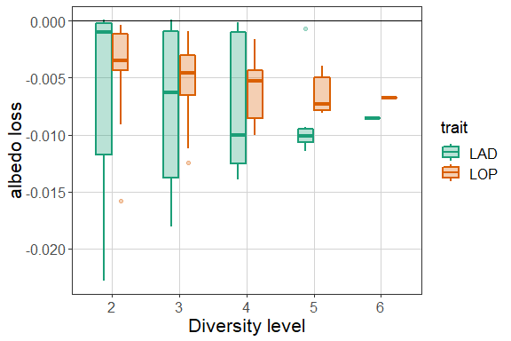

```r
ggplot(subset(dat, background == "white" & illumination == "direct sun, 0° zenith angle  "),
       aes(x = num_of_species, y = differences, col = trait, fill = trait)) +
  geom_boxplot(width=0.5, alpha = 0.3, size = 0.75) +
  geom_hline(yintercept = 0) +
  xlab("Diversity level") + ylab("albedo loss") + theme_bw() +
  scale_color_brewer(palette="Dark2") +
  scale_fill_brewer(palette="Dark2") +
  theme(panel.grid.major = element_line(colour = "lightgrey"), panel.grid.minor = element_blank(),
        plot.title = element_text(size=16, hjust = 0.5),
        axis.title.x = element_text(size=16), axis.text.x  = element_text(size=12),
        axis.title.y = element_text(size=16), axis.text.y  = element_text(size=12),
        strip.text.x = element_text(size = 14), strip.text.y = element_text(size = 14),
        legend.text = element_text(size=12), legend.title = element_text(size=14), title = element_text(size=16))
```

```r
ggplot(subset(dat, background == "black" & illumination == "direct sun, 30° zenith angle   "),
       aes(x = num_of_species, y = differences, col = trait, fill = trait)) +
  geom_boxplot(width=0.5, alpha = 0.3, size = 0.75) + geom_point() +
  geom_hline(yintercept = 0) +
  xlab("Diversity level") + ylab("albedo loss") + theme_bw() +
  scale_color_brewer(palette="Dark2") +
  scale_fill_brewer(palette="Dark2") +
  theme(panel.grid.major = element_line(colour = "lightgrey"), panel.grid.minor = element_blank(),
        plot.title = element_text(size=16, hjust = 0.5),
        axis.title.x = element_text(size=16), axis.text.x  = element_text(size=12),
        axis.title.y = element_text(size=16), axis.text.y  = element_text(size=12),
        strip.text.x = element_text(size = 14), strip.text.y = element_text(size = 14),
        legend.text = element_text(size=12), legend.title = element_text(size=14), title = element_text(size=16))
```

Supplementary Fig. 1

```r
dat$trait = factor(dat$trait, levels=c("LOP", "LAD"))
ggplot(dat, aes(x = num_of_species, y = differences, col = illumination, fill = illumination)) +
  geom_boxplot(width=0.5, alpha = 0.3, size = 0.7) +
  geom_hline(yintercept = 0) +
  xlab("PFT diversity level") + ylab("albedo loss") + theme_bw() +
  scale_color_brewer(palette="Dark2") +
  scale_fill_brewer(palette="Dark2") +
  scale_y_continuous(breaks = seq(-0.5,0,0.005)) +
  facet_grid(background~trait, space = "free", scales = "free") +
  theme(legend.position="bottom") +
  theme(panel.grid.major = element_line(colour = "lightgrey"), panel.grid.minor.x = element_blank(),
        plot.title = element_text(size=16, hjust = 0.5),
        axis.title.x = element_text(size=16), axis.text.x  = element_text(size=12),
        axis.title.y = element_text(size=16), axis.text.y  = element_text(size=12),
        strip.text.x = element_text(size = 14), strip.text.y = element_text(size = 14),
        legend.text = element_text(size=12), legend.title = element_text(size=14), title = element_text(size=16))
```

[figure not shown]

```r
dat$trait = factor(dat$trait, levels=c("LOP", "LAD"))
ggplot(dat, aes(x = num_of_species, y = differences, col = illumination, fill = illumination)) +
  geom_smooth(aes(group = illumination), method = lm, formula = y ~ splines::bs(x, 3), se = T, alpha = 0.2) +
  #geom_point(size = 2) +
  #geom_violin(width=1.4) +
  #geom_boxplot(width=0.5, alpha = 0.1) +
  geom_hline(yintercept = 0) +
  xlab("PFT diversity level") + ylab("gain in albedo") + theme_bw() +
  scale_color_brewer(palette="Dark2") +
  scale_fill_brewer(palette="Dark2") +
  scale_y_continuous(breaks = seq(-0.5,0,0.005)) +
  facet_grid(background~trait, space = "free", scales = "free") +
  theme(legend.position="bottom") +
  theme(panel.grid.major = element_line(colour = "lightgrey"), panel.grid.minor.x = element_blank(),
        plot.title = element_text(size=16, hjust = 0.5),
        axis.title.x = element_text(size=16), axis.text.x  = element_text(size=12),
        axis.title.y = element_text(size=16), axis.text.y  = element_text(size=12),
        strip.text.x = element_text(size = 14), strip.text.y = element_text(size = 14),
        legend.text = element_text(size=12), legend.title = element_text(size=14), title = element_text(size=16))
```

```r
levels(lop$species) = c("beech", "deciduous", "elm", "eucalyptus", "aspen", "pine")
```

```
Error in levels(lop$species) = c("beech", "deciduous", "elm", "eucalyptus",  :
  object 'lop' not found
```

```r
levels(lop$species) = c("beech", "deciduous", "elm", "eucalyptus", "aspen", "pine")
lop_ov = read_data(path_lop_ov)
levels(lop_ov$species) = c("beech", "deciduous", "elm", "eucalyptus", "aspen", "pine")
lad = read_data(path_lad)
levels(lad$species) = c("Spherical", "Uniform", "Vertical", "Horizontal", "Ellipsoidal", "Extremophile")
lad_ov = read_data(path_lad_ov)
levels(lad_ov$species) = c("Spherical", "Uniform", "Vertical", "Horizontal", "Ellipsoidal", "Extremophile")
```

```r
aggdat = aggregate(albedo ~ pos + num_of_species, data = lad, FUN = "mean")
cumsumm = cumsum(unlist(sapply(c(1:Nspecies), function(x) choose(Nspecies, x))))
diffsl = lapply(c(2:Nspecies), function(k) sapply(c(1:choose(Nspecies, k)), function(i)
  aggdat$albedo[i+cumsumm[k-1]] - sum(aggdat$albedo[combn(Nspecies, k)[,i]])/k))
diffsl = as.data.frame(cbind(unlist(diffsl), aggdat$num_of_species[-c(1:6)]))
colnames(diffsl) = c("differences", "num_of_species")
diffsl$num_of_species = as.factor(diffsl$num_of_species)

diffsl$trait = "LAD"

aggdat = aggregate(albedo ~ pos + num_of_species, data = lad_ov, FUN = "mean")
cumsumm = cumsum(unlist(sapply(c(1:Nspecies), function(x) choose(Nspecies, x))))
diffslad = lapply(c(2:Nspecies), function(k) sapply(c(1:choose(Nspecies, k)), function(i)
  aggdat$albedo[i+cumsumm[k-1]] - sum(aggdat$albedo[combn(Nspecies, k)[,i]])/k))
diffslad = as.data.frame(cbind(unlist(diffsl), aggdat$num_of_species[-c(1:6)]))
colnames(diffslad) = c("differences", "num_of_species")
diffslad$num_of_species = as.factor(diffsl$num_of_species)

diffslad$trait = "LAD_overcasted"

aggdat = aggregate(albedo ~ pos + num_of_species, data = lop, FUN = "mean")
cumsumm = cumsum(unlist(sapply(c(1:Nspecies), function(x) choose(Nspecies, x))))
diffs = lapply(c(2:Nspecies), function(k) sapply(c(1:choose(Nspecies, k)), function(i)
  aggdat$albedo[i+cumsumm[k-1]] - sum(aggdat$albedo[combn(Nspecies, k)[,i]])/k))
diffs = as.data.frame(cbind(unlist(diffs), aggdat$num_of_species[-c(1:6)]))
colnames(diffs) = c("differences", "num_of_species")
diffs$num_of_species = as.factor(diffs$num_of_species)

diffs$trait = "LOP"

aggdat = aggregate(albedo ~ pos + num_of_species, data = lop_ov, FUN = "mean")
cumsumm = cumsum(unlist(sapply(c(1:Nspecies), function(x) choose(Nspecies, x))))
diffslop = lapply(c(2:Nspecies), function(k) sapply(c(1:choose(Nspecies, k)), function(i)
  aggdat$albedo[i+cumsumm[k-1]] - sum(aggdat$albedo[combn(Nspecies, k)[,i]])/k))
diffslop = as.data.frame(cbind(unlist(diffslop), aggdat$num_of_species[-c(1:6)]))
colnames(diffslop) = c("differences", "num_of_species")
diffslop$num_of_species = as.factor(diffslop$num_of_species)

diffslop$trait = "LOP_overcasted"

diffs = rbind(diffs, diffslop, diffsl, diffslad)

ggplot(diffs, aes(x = num_of_species, y = differences, col = trait, fill = trait)) +
  #geom_point(size = 2) +
  #geom_violin(width=1.4) +
  geom_boxplot(width=0.5, alpha = 0.3) +
  geom_hline(yintercept = 0) +
  xlab("number of species") + ylab("differences with average of monocultures") + theme_bw() +
  scale_color_brewer(palette="Dark2") +
  scale_fill_brewer(palette="Dark2") +
 theme(panel.grid.major = element_line(colour = "lightgrey"), panel.grid.minor = element_blank(),
        plot.title = element_text(size=16, hjust = 0.5),
        axis.title.x = element_text(size=16), axis.text.x  = element_text(size=12),
        axis.title.y = element_text(size=16), axis.text.y  = element_text(size=12),
        strip.text.x = element_text(size = 14), strip.text.y = element_text(size = 14),
        legend.text = element_text(size=12), legend.title = element_text(size=14), title = element_text(size=16))
```

```r
aggdat = aggregate(albedo ~ pos + num_of_species, data = lad, FUN = "mean")
cumsumm = cumsum(unlist(sapply(c(1:Nspecies), function(x) choose(Nspecies, x))))
diffs = lapply(c(2:Nspecies), function(k) sapply(c(1:choose(Nspecies, k)), function(i)
  aggdat$albedo[i+cumsumm[k-1]] - sum(aggdat$albedo[combn(Nspecies, k)[,i]])/k))
diffs = as.data.frame(cbind(unlist(diffs), aggdat$num_of_species[-c(1:6)]))
colnames(diffs) = c("differences", "num_of_species")
diffs$num_of_species = as.factor(diffs$num_of_species)

diffs$trait = "LAD"

aggdat = aggregate(albedo ~ pos + num_of_species, data = lad_ov, FUN = "mean")
cumsumm = cumsum(unlist(sapply(c(1:Nspecies), function(x) choose(Nspecies, x))))
diffslop = lapply(c(2:Nspecies), function(k) sapply(c(1:choose(Nspecies, k)), function(i)
  aggdat$albedo[i+cumsumm[k-1]] - sum(aggdat$albedo[combn(Nspecies, k)[,i]])/k))
diffslop = as.data.frame(cbind(unlist(diffslop), aggdat$num_of_species[-c(1:6)]))
colnames(diffslop) = c("differences", "num_of_species")
diffslop$num_of_species = as.factor(diffslop$num_of_species)

diffslop$trait = "LAD_overcasted"

diffs = rbind(diffs, diffslop)

ggplot(diffs, aes(x = num_of_species, y = differences, col = trait, fill = trait)) +
  geom_boxplot(width=0.5, alpha = 0.3) +
  geom_hline(yintercept = 0) +
  xlab("number of species") + ylab("differences with average of monocultures") + theme_bw() +
  scale_color_brewer(palette="Dark2") +
  scale_fill_brewer(palette="Dark2") +
 theme(panel.grid.major = element_line(colour = "lightgrey"), panel.grid.minor = element_blank(),
        plot.title = element_text(size=16, hjust = 0.5),
        axis.title.x = element_text(size=16), axis.text.x  = element_text(size=12),
        axis.title.y = element_text(size=16), axis.text.y  = element_text(size=12),
        strip.text.x = element_text(size = 14), strip.text.y = element_text(size = 14),
        legend.text = element_text(size=12), legend.title = element_text(size=14), title = element_text(size=16))
```

```r
aggdat = aggregate(albedo ~ pos + num_of_species, data = lad, FUN = "mean")
cumsumm = cumsum(unlist(sapply(c(1:Nspecies), function(x) choose(Nspecies, x))))
diffs = lapply(c(2:Nspecies), function(k) sapply(c(1:choose(Nspecies, k)), function(i)
  aggdat$albedo[i+cumsumm[k-1]] - sum(aggdat$albedo[combn(Nspecies, k)[,i]])/k))
diffs = as.data.frame(cbind(unlist(diffs), aggdat$num_of_species[-c(1:6)]))
colnames(diffs) = c("differences", "num_of_species")
diffs$num_of_species = as.factor(diffs$num_of_species)

diffs$trait = "LAD"

aggdat = aggregate(albedo ~ pos + num_of_species, data = lop, FUN = "mean")
cumsumm = cumsum(unlist(sapply(c(1:Nspecies), function(x) choose(Nspecies, x))))
diffslop = lapply(c(2:Nspecies), function(k) sapply(c(1:choose(Nspecies, k)), function(i)
  aggdat$albedo[i+cumsumm[k-1]] - sum(aggdat$albedo[combn(Nspecies, k)[,i]])/k))
diffslop = as.data.frame(cbind(unlist(diffslop), aggdat$num_of_species[-c(1:6)]))
colnames(diffslop) = c("differences", "num_of_species")
diffslop$num_of_species = as.factor(diffslop$num_of_species)

diffslop$trait = "LOP"

diffs = rbind(diffs, diffslop)

ggplot(diffs, aes(x = num_of_species, y = differences, col = trait, fill = trait)) +
  #geom_point(size = 2) +
  #geom_violin(width=1.4) +
  geom_boxplot(width=0.5, alpha = 0.3) +
  geom_hline(yintercept = 0) +
  xlab("number of species") + ylab("diff betw mixtures and monocultures") + theme_bw() +
  scale_color_brewer(palette="Dark2") +
  scale_fill_brewer(palette="Dark2") +
 theme(panel.grid.major = element_line(colour = "lightgrey"), panel.grid.minor = element_blank(),
        plot.title = element_text(size=16, hjust = 0.5),
        axis.title.x = element_text(size=16), axis.text.x  = element_text(size=12),
        axis.title.y = element_text(size=16), axis.text.y  = element_text(size=12),
        strip.text.x = element_text(size = 14), strip.text.y = element_text(size = 14),
        legend.text = element_text(size=12), legend.title = element_text(size=14), title = element_text(size=16))
```

We can see that differences in albedo between mixtures and monocultures are negative, which means that albedo of mixtures is lower. The magnitude of difference is up to 2.5%.

## Absorption of the trees

Profiles of absorption of different species (differ by LOP) in different mixtures (1 - 6 species)

```r
subdat_crown = lop
ann_text_first <- data.frame(label = sapply(levels(subdat_crown$species), function(x)
  round(sum(subdat_crown$abs_mean[subdat_crown$species == x & subdat_crown$num_of_species == 1]), 2 )),
  num_of_species = rep(factor(1,levels = levels(subdat_crown$num_of_species)), Nspecies),
  species = factor(levels(subdat_crown$species),levels = levels(subdat_crown$species)))

ann_text_last <- data.frame(label = sapply(levels(subdat_crown$species), function(x)
  round(sum(subdat_crown$abs_mean[subdat_crown$species == x & subdat_crown$num_of_species == Nspecies]), 2 )),
  num_of_species = rep(factor(Nspecies,levels = levels(subdat_crown$num_of_species)), Nspecies),
  species = factor(levels(subdat_crown$species),levels = levels(subdat_crown$species)))


ggplot(data = subdat_crown,
       aes(x = height_m, y = abs_mean, col = num_of_species)) +
  stat_summary(aes(col = num_of_species), fun.y = 'mean', geom = 'line', size = 1.4) +
  stat_summary(aes(fill = num_of_species), fun.data = 'mean_sdl', geom = 'ribbon', alpha = 0.2,
               fun.args = list(mult = 1)) +

  scale_y_continuous(breaks = seq(0,0.15,0.05)) +
  facet_grid(~species, space = "free", scales = "free") +
  geom_text(data  = ann_text_first, mapping = aes(x = -Inf, y = -Inf, label = label),
            hjust = -0.5, vjust   = -20, show.legend = FALSE, size = 4.5) +
  geom_text(data  = ann_text_last, mapping = aes(x = -Inf, y = -Inf, label = label),
            hjust = -0.5, vjust   = -18, show.legend = FALSE, size = 4.5) +
  ylab("proportion of absorbed light")  + theme_bw() + xlab("height, m") + ggtitle("Species") +
  scale_color_brewer(palette="Spectral", guide = guide_legend(title = "PFT diversity level", nrow = 1)) +
  scale_fill_brewer(palette="Spectral")  + coord_flip() +
   theme(panel.grid.major = element_line(colour = "lightgrey"), panel.grid.minor = element_blank(),
        plot.title = element_text(size=16, hjust = 0.5),
        axis.title.x = element_text(size=16), axis.text.x  = element_text(size=12),
        axis.title.y = element_text(size=16), axis.text.y  = element_text(size=12),
        strip.text.x = element_text(size = 14), strip.text.y = element_text(size = 14),
        legend.text = element_text(size=12), legend.title = element_text(size=14), title = element_text(size=16)) +
  theme(legend.position="bottom", legend.box = "horizontal", legend.direction = "horizontal")
```

- red number indicate average absorptance of a tree of certain specie in monocultures, blue number indicate average absorptance of a tree of certain specie in mixture of 6 species.

Here we observe the opposite tendencies in light redistribution of beech tree and elm: beech tree tend to absorb more in mixtures, while elm tend to absorb less.

In order to understand the process better, we present here the same graphs for the black and “white - black” backgrounds.

- Simulation with black background shows all the light absorbed before the first hit to the ground.
- Simulation with “white - black” background shows all the light absorbed after reflection from lambertian while background.

```r
subdat = dat[dat$band == WAVE_RANGE &  dat$scenetype == 2,]
subdat_crown = as.data.frame(subdat[subdat$height_m != 1,])
subdat_scene = subdat[subdat$height_m == 1,]
```

### Black background

```r
ann_text_first <- data.frame(label = sapply(levels(subdat_crown$species), function(x)
  round(sum(subdat_crown$abs_mean[subdat_crown$species == x & subdat_crown$num_of_species == 1]), 2 )),
  num_of_species = rep(factor(1,levels = levels(subdat_crown$num_of_species)), Nspecies),
  species = factor(levels(subdat_crown$species),levels = levels(subdat_crown$species)))

ann_text_last <- data.frame(label = sapply(levels(subdat_crown$species), function(x)
  round(sum(subdat_crown$abs_mean[subdat_crown$species == x & subdat_crown$num_of_species == Nspecies]), 2 )),
  num_of_species = rep(factor(Nspecies,levels = levels(subdat_crown$num_of_species)), Nspecies),
  species = factor(levels(subdat_crown$species),levels = levels(subdat_crown$species)))


ggplot(data = subdat_crown,
       aes(x = height_m, y = abs_mean, col = num_of_species)) +
  stat_summary(aes(col = num_of_species), fun.y = 'mean', geom = 'line', size = 1.4) +
  stat_summary(aes(fill = num_of_species), fun.data = 'mean_sdl', geom = 'ribbon', alpha = 0.2,
               fun.args = list(mult = 1)) +

  scale_y_continuous(breaks = seq(0,0.15,0.05)) +
  facet_grid(~species, space = "free", scales = "free") +
  geom_text(data  = ann_text_first, mapping = aes(x = -Inf, y = -Inf, label = label),
            hjust = -0.5, vjust   = -25, show.legend = FALSE, size = 4.5) +
  geom_text(data  = ann_text_last, mapping = aes(x = -Inf, y = -Inf, label = label),
            hjust = -0.5, vjust   = -23, show.legend = FALSE, size = 4.5) +
  #geom_text(data = ann_text,label = as.character(ann_text$label), show.legend = FALSE) +

  ylab("proportion of absorbed light")  + theme_bw() + xlab("height, m") + ggtitle("Species") +
  scale_color_brewer(palette="Spectral") + scale_fill_brewer(palette="Spectral")  + coord_flip() +
  theme(panel.grid.major = element_line(colour = "lightgrey"), panel.grid.minor = element_blank(),
        plot.title = element_text(size=16, hjust = 0.5),
        axis.title.x = element_text(size=16), axis.text.x  = element_text(size=12),
        axis.title.y = element_text(size=16), axis.text.y  = element_text(size=12),
        strip.text.x = element_text(size = 14), strip.text.y = element_text(size = 14),
        legend.text = element_text(size=12), legend.title = element_text(size=14), title = element_text(size=16))
```

The effect stays the same, but it is much smaller.

```r
subdat = dat[dat$band == WAVE_RANGE &  dat$scenetype == 1 & dat$height_m != 1,]
black_albedo = dat[dat$band == WAVE_RANGE &  dat$scenetype == 2 & dat$height_m != 1, "albedo"]
subdat$albedo = subdat$albedo - black_albedo
black_abs = dat[dat$band == WAVE_RANGE &  dat$scenetype == 2 & dat$height_m != 1, "abs_mean"]
subdat$abs_mean = subdat$abs_mean - black_abs
subdat_crown = as.data.frame(subdat[subdat$height_m != 1,])
subdat_scene = subdat[subdat$height_m == 1,]
```

### “Black - white” background

```r
ann_text_first <- data.frame(label = sapply(levels(subdat_crown$species), function(x)
  round(sum(subdat_crown$abs_mean[subdat_crown$species == x & subdat_crown$num_of_species == 1]), 2 )),
  num_of_species = rep(factor(1,levels = levels(subdat_crown$num_of_species)), Nspecies),
  species = factor(levels(subdat_crown$species),levels = levels(subdat_crown$species)))

ann_text_last <- data.frame(label = sapply(levels(subdat_crown$species), function(x)
  round(sum(subdat_crown$abs_mean[subdat_crown$species == x & subdat_crown$num_of_species == Nspecies]), 2 )),
  num_of_species = rep(factor(Nspecies,levels = levels(subdat_crown$num_of_species)), Nspecies),
  species = factor(levels(subdat_crown$species),levels = levels(subdat_crown$species)))


ggplot(data = subdat_crown,
       aes(x = height_m, y = abs_mean, col = num_of_species)) +
  stat_summary(aes(col = num_of_species), fun.y = 'mean', geom = 'line', size = 1.4) +
  stat_summary(aes(fill = num_of_species), fun.data = 'mean_sdl', geom = 'ribbon', alpha = 0.2,
               fun.args = list(mult = 1)) +

  scale_y_continuous(breaks = seq(0,0.15,0.01)) +
  facet_grid(~species, space = "free", scales = "free") +
  geom_text(data  = ann_text_first, mapping = aes(x = -Inf, y = -Inf, label = label),
            hjust = -0.5, vjust   = -25, show.legend = FALSE, size = 4.5) +
  geom_text(data  = ann_text_last, mapping = aes(x = -Inf, y = -Inf, label = label),
            hjust = -0.5, vjust   = -23, show.legend = FALSE, size = 4.5) +
  #geom_text(data = ann_text,label = as.character(ann_text$label), show.legend = FALSE) +

  ylab("proportion of absorbed light")  + theme_bw() + xlab("height, m") + ggtitle("Species") +
  scale_color_brewer(palette="Spectral") + scale_fill_brewer(palette="Spectral")  + coord_flip() +
  theme(panel.grid.major = element_line(colour = "lightgrey"), panel.grid.minor = element_blank(),
        plot.title = element_text(size=16, hjust = 0.5),
        axis.title.x = element_text(size=16), axis.text.x  = element_text(size=12),
        axis.title.y = element_text(size=16), axis.text.y  = element_text(size=12),
        strip.text.x = element_text(size = 14), strip.text.y = element_text(size = 14),
        legend.text = element_text(size=12), legend.title = element_text(size=14), title = element_text(size=16))
```

As we can see, most of the variation occurs in the “black” scene, before light hit the ground.

When we compare LOP of these species in the Visible range, we can see that elm has the largest transmittance, while beech tree has the largest absorbtance value.

As beech and elm showed the largest effects, we investigated light redistribution in their combination:

```r
sp_of_interest = subset(dat, height_m != 1 & band == "VIS" & pos %in% c(1,3,8))

sp_of_interest$pos = as.factor(sp_of_interest$pos)
levels(sp_of_interest$pos) = c("mon", "mon", "mix")
#Nspecies = 2
#mix_tab = diff_betw_mix_and_av_of_mon(sp_of_interest)
sp_of_interest$scenetype = as.factor(sp_of_interest$scenetype)
levels(sp_of_interest$scenetype) = c("white", "black", "natural")

sp_of_interest_wh_bl = sp_of_interest[sp_of_interest$scenetype == "natural",]
sp_of_interest_wh_bl$abs_mean = sp_of_interest$abs_mean[sp_of_interest$scenetype == "white"] -
  sp_of_interest$abs_mean[sp_of_interest$scenetype == "black"]
sp_of_interest_wh_bl$scenetype = "white - black"
sp_of_interest = as.data.frame(rbind(sp_of_interest, sp_of_interest_wh_bl))
sp_of_interest$scenetype = factor(sp_of_interest$scenetype,c("white", "black", "white - black", "natural"))

ggplot(data = sp_of_interest,
       aes(x = height_m, y = abs_mean, col = interaction(pos, species), group = interaction(pos, species))) +
  geom_line(size = 1.2) +
  ylab("proportion of absorbed light")  + theme_bw() + xlab("height, m") +
  ggtitle("type of background") +
  scale_color_brewer(palette = "Paired", direction = -1) +
  coord_flip() +
  facet_grid(~scenetype, space = "free", scales = "free") +
  scale_y_continuous(breaks = seq(0,0.14,0.05)) +
  theme(panel.grid.major = element_line(colour = "lightgrey"), panel.grid.minor.y = element_blank(),
        plot.title = element_text(size=16, hjust = 0.5),
        axis.title.x = element_text(size=16), axis.text.x  = element_text(size=12),
        axis.title.y = element_text(size=16), axis.text.y  = element_text(size=12),
        strip.text.x = element_text(size = 14), strip.text.y = element_text(size = 14),
        legend.text = element_text(size=12), legend.title = element_text(size=14), title = element_text(size=16))
```

We can see that beech absorb more light and gain light in mixtures, while elm absorbs less and lose the light in mixtures.

From this and simmilar experiments we assumed that H1: A tree with higher absorptance gain more light in mixtures, while trees with lower absorptance loose light We tested H1 for all combinations of 2 trees, by representing difference betw mixt and mono on one axis and absorptance in monocultures in another axis:

```r
sp_of_interest = subset(dat, height_m != 1 & band == WAVE_RANGE & num_of_species %in% c(1,2), select = c("num_of_species", "species", "pos", "scenetype", "height_m", "abs_mean"))


sp_of_interest$scenetype = as.factor(sp_of_interest$scenetype)
levels(sp_of_interest$scenetype) = c("white", "black", "natural")


whbl_subdat = merge(sp_of_interest[sp_of_interest$scenetype == "white",],
                    sp_of_interest[sp_of_interest$scenetype == "black",],
                      by = c("num_of_species", "species", "pos", "height_m"))
whbl_subdat$abs_mean = whbl_subdat$abs_mean.x - whbl_subdat$abs_mean.y
whbl_subdat$scenetype = "white - black"
whbl_subdat = subset(whbl_subdat, select = c("num_of_species", "species", "pos", "scenetype", "height_m", "abs_mean"))

sp_of_interest = as.data.frame(rbind(sp_of_interest, whbl_subdat))
sp_of_interest$scenetype = factor(sp_of_interest$scenetype,c("white", "black", "white - black", "natural"))
mix_tab = diff_betw_sp_in_mix_and_in_mon(sp_of_interest)
mix_tab = diff_betw_sp_in_mix_and_in_mon(sp_of_interest)
ggplot(data = mix_tab,
       aes(x = mon_abs, y = abs_mean, col = as.factor(name_species), group = as.factor(pos)) ) +
  geom_point() + geom_line() +
  geom_hline(aes(yintercept = 0), col = "gray35") +
  ylab("Diffrence in absorbtance of mixtures minus monocultures")  +
  theme_bw() + xlab("absorptance in monoculture") +
  ggtitle("type of background") +
  coord_flip() +
  facet_grid(~scenetype, space = "free", scales = "free") +
  scale_y_continuous(breaks = seq(-1,0.15,0.05)) +
  theme(panel.grid.major = element_line(colour = "lightgrey"), panel.grid.minor.y = element_blank(),
        #panel.grid.major.y = element_blank(),
        plot.title = element_text(size=16, hjust = 0.5),
        axis.title.x = element_text(size=16), axis.text.x  = element_text(size=12),
        axis.title.y = element_text(size=16), axis.text.y  = element_text(size=12),
        strip.text.x = element_text(size = 14), strip.text.y = element_text(size = 14),
        legend.text = element_text(size=12), legend.title = element_text(size=14), title = element_text(size=16))
```

The H1 holds true in the most of cases, with 2 exceptions. We further show this dependance analytically on more simple model (in the next report).

## Difference in absorptance values of trees in mixtures and average of monocultures’ absorptance values

E.g. for #species = 2:
$$albedo(species_1 , species_2) - \frac{albedo(species_1) + albedo(species_2)}{2}$$

The difference is shown on different backgrounds.

```r
library(viridis)
sp_of_interest = subset(dat, height_m != 1 & band == WAVE_RANGE, select = c("num_of_species", "species", "pos", "scenetype", "height_m", "abs_mean"))

sp_of_interest$scenetype = as.factor(sp_of_interest$scenetype)
levels(sp_of_interest$scenetype) = c("white", "black", "natural")

whbl_subdat = merge(sp_of_interest[sp_of_interest$scenetype == "white",],
                    sp_of_interest[sp_of_interest$scenetype == "black",],
                      by = c("num_of_species", "species", "pos", "height_m"))
whbl_subdat$abs_mean = whbl_subdat$abs_mean.x - whbl_subdat$abs_mean.y
whbl_subdat$scenetype = "white - black"
whbl_subdat = subset(whbl_subdat, select = c("num_of_species", "species", "pos", "scenetype", "height_m", "abs_mean"))

sp_of_interest = as.data.frame(rbind(sp_of_interest, whbl_subdat))
sp_of_interest$scenetype = factor(sp_of_interest$scenetype,c("white", "black", "white - black", "natural"))
mix_tab = diff_betw_mix_and_av_of_mon(sp_of_interest)


#mix_tab = diff_betw_mix_and_av_of_mon(dat)

ggplot(data = mix_tab,
       aes(x = height_m, y = abs_mean, col = diff_sum, group = as.factor(pos))) +
  geom_line(size = 1) +
  ylab("proportion of absorbed light")  + theme_bw() + xlab("height, m") +
  ggtitle("type of background") +
  scale_color_viridis(option="inferno") +
  coord_flip() +
  facet_grid(~scenetype, space = "free", scales = "free") +
  scale_y_continuous(breaks = seq(0,0.15,0.002)) +
  theme(panel.grid.major = element_line(colour = "lightgrey"), panel.grid.minor.y = element_blank(),
        plot.title = element_text(size=16, hjust = 0.5),
        axis.title.x = element_text(size=16), axis.text.x  = element_text(size=12),
        axis.title.y = element_text(size=16), axis.text.y  = element_text(size=12),
        strip.text.x = element_text(size = 14), strip.text.y = element_text(size = 14),
        legend.text = element_text(size=12), legend.title = element_text(size=14), title = element_text(size=16))
```

As we can see, the contribution of the light prior to the first hit of background larger than after it: if the total difference in absorptances is 2.5%, then 2% was absorbed before the first hit of backgound (black scene) and 0.5% after the reflection from the white scene (white-black scene). The effect is even larger for canopy itself, and opposite for the trunk. Light absorption profiles with natural background are similar to the white and black backgrounds.